# Visualización y geolocalización de datos

Máster en Data Science & Business Analytics (con R Software)

Gema Fernández-Avilés

Diego Hernangómez

2022-01-10

**Objetivos de aprendizaje**

**¿Por dónde empezamos? Recursos interesantes**

Web:

- [rspatial](https://rspatial.org/)
- [R-spatial](https://r-spatial.org/projects/)

Libros de referencia:

- [Spatial Data Science with applications in R](https://keen-swartz-3146c4.netlify.app/)
- [Geocomputation with R](https://geocompr.robinlovelace.net/)
- [Displaying time series, spatial and space-time data with R](https://oscarperpinan.github.io/bookvis/)

# 1 La revolución de los geodatos

Que estamos en la la *era del dato*, que los *datos son el petroleo del siglo XXI* y que estamos rodeados de datos es una cuestión que ya hemos hecho inherente a nosotros. Estamos en el momento del dato, donde la profesión de Data Scientist se ha convertido en la *profesión más sexy del siglo XXI* según vaticinó en 2012 *Harvard Business Review*. Cada segundo se producen 1,7 MB de datos/persona y cada año esta cifra se duplica se duplica.

Este incremento exponencial de los datos ha sido posible, sin duda, gracias al desarrollo de la tecnología, los ordenadores, los teléfonos móviles móviles, los satélites, internet, etc… y asociado a estas nuevas herramientas, se ha producido una lluvia sin precedentes hasta el momento de datos espaciales o datos georreferenciados. Cada teléfono inteligente tiene un receptor de posicionamiento global (GPS) y una multitud de sensores en dispositivos que van desde satélites y vehículos semiautónomos hasta científicos ciudadanos que miden incesantemente cada parte del mundo. La tasa de datos producidos es abrumadora. Un vehículo autónomo, por ejemplo, puede generar 100 GB de datos por día (The Economist, 2016). Los datos de teledetección de satélites se han vuelto demasiado grandes para analizar los datos correspondientes con una sola computadora.

Esta **revolución de los geodatos** y el **análisis de los datos espaciales** no sólo impulsa la demanda de hardware informático de alto rendimiento y software escalable y eficiente para manejar y extraer la señal del ruido, lo que se conoce como **Geocomputación**, sino que ha dado lugar una nueva rama de conocimiento, *Spatial Data Scicene* (SDS) o **Ciencia de Datos Espaciales**.

# 2 Geocomputación y R-spatial

La geocomputación es un término relativamente nuevo pero influenciado por otros términos clasiscos. Es decir, puede ser visto como una parte de la Geografía, la cual tiene más de 2000 años de historia (Talbert_2014) o como una extensión de los Sistemas de Información Geográfica comunmente conocidos por GIS (del inglés, Geographic Information Systems) (Neteler and Mitasova 2008), los cuales emergieron en la década de los 60 (Coppock and Rhind 1991).

Según Lovelace, Nowosad, & Muenchow (2019), el término Geocomputación se utilizó por primera vez en 1996 en la primera conferencia que trataba de Geocomputación. Abrahart, Openshaw, Abrahart, & See (2000) definenen la geocomputación como una herramienta que trata de utilizar los diferentes tipos de datos geográficos y de desarrollar herramientas geográficas relevantes dentro del contexto general de un enfoque ‘científico.’

La geocomputación está estrechamente relacionada con otros términos que incluyen:

- la ciencia de la información geográfica (GIScience),
- la geomática,
- la Geoinformática,
- la ciencia de la información espacial
- la ingeniería de Geoinformación (P. Longley 2015)
- y ciencia de datos geográficos (GDS, Geographic Data Science).

Cada término comparte un énfasis en un enfoque **científico** (que implica reproducible y falsable) influenciado por los SIG, aunque sus orígenes y principales campos de aplicación difieren.

La ciencia de datos geográficos, por ejemplo, enfatiza las habilidades de “ciencia de datos” y grandes conjuntos de datos, mientras que la geoinformática tiende a enfocarse en estructuras de datos. Pero las superposiciones entre los términos son más grandes que las diferencias entre ellos y usamos geocomputación como un sinónimo aproximado que los encapsula a todos: todos buscan usar datos geográficos para trabajos científicos aplicados.

# 3 Estadística espacial

La estadística espacial reconoce y aprovecha la ubicación espacial de los datos a la hora de diseñar, recopilar, gestionar, analizar y mostrar las observaciones. Éstas son generalmente **dependientes**, si bien existen modelos espaciales a disposición del investigador que permiten tratar con dicha dependencia espacial a la hora de llevar a cabo labores de predicción. La estadística espacio-temporal incorpora, además, el tiempo y su interacción con el espacio como argumento de ayuda en tales labores predictivas.

Las mediciones y modelos espaciales están presentes, sorprendentemente, en una amplia variedad de disciplinas científicas. Los orígenes de la vida humana vinculan los estudios de la evolución de las galaxias, la estructura de las células biológicas y los patrones de asentamiento arqueológicos. Los ecologistas estudian las interacciones entre plantas y animales. Silvicultores y agricultores necesitan investigar las variaciones que se producen en el terreno para sus experimentos. La estimación de las precipitaciones y de las reservas de oro y petróleo es de vital importancia económica. Estos son, entre otros, buenos ejemplos de la importancia del espacio (espacio-tiempo en su caso) en el mundo de la Ciencia.

En todo caso, la geología, la edafología, el tratamiento de imágenes, la epidemiología, la agronomía, la ecología, la silvicultura, la astronomía, el estudio de la atmósfera, la economía, o simplemente, cualquier disciplina que trabaje con datos espaciales recopilados de diferentes lugares y en distintos instantes temporales, necesita del desarrollo de modelos geoestadísticos que indiquen la estructura e intensidad de la dependencia espacial y/o espacio-temporal presente en los fenómenos que comprenden.

Sin embargo, el estudio de la **variabilidad espacial**, y sobre todo espacio-temporal, es una disciplina relativamente nueva en el marco de la Estadística, lo que explica la escasez de instrumentos de estadística espacial 30 años atrás. En los últimos 10 años ha habido una creciente toma de conciencia de esta necesidad, habiéndose realizado un gran esfuerzo por buscar herramientas adecuadas y útiles a tales efectos. Y todo ello porque utilizar modelos espaciales o espacio-temporales para caracterizar y explotar la dependencia espacial (o espacio-temporal) de un conjunto de observaciones tiene importantes ventajas:

1. Modelos más generales, ya que, en la mayoría de los casos, los modelos clásicos que no tienen en consideración la dimensión espacial o la interacción de las dimensiones espacial y temporal son un caso particular de un modelo espacial o espacio-temporal.
2. Estimaciones más eficientes: de la tendencia, de los efectos de las variables explicativas, de promedios regionales,…
3. Mejora de las predicciones: más eficientes, con propiedades de extrapolación más estables,…
4. La variación espacial no explicada en la estructura de la media debe ser absorbida por la estructura del error, por lo que un modelo que incorpore la dependencia espacial puede decirse que está protegido frente a una mala especificación de este tipo. Esto, en muchos casos, tiene como resultado una simplificación en la especificación de la tendencia; en general, los modelos con dependencia espacial suelen tener una descripción más parsimoniosa (en ocasiones con muchos menos parámetros) que los clásicos modelos de superficie de tendencia.

Estas mejoras de la estadística espacial y espacio-temporal, junto con el fuerte y reciente desarrollo de los Sistemas de Información Geográfica o GIS (Geographic Information System), han propiciado que en la actualidad exista una importante motivación por la búsqueda de herramientas espaciales o espacio-temporales.

## 3.1 Antes de continuar… dependencia espacial.

Frecuentemente los datos tienen una componente espacial y/o temporal asociada a ellos y es de esperar que datos cercanos en el espacio o en el tiempo sean más semejantes que aquellos que están más alejados; en cuyo caso **no** deben ser modelados como estadísticamente independiente, sino que habrá que tomar en cuenta esa dependencia espacial o espacio-temporal.

De forma natural y de acuerdo a la Ley Tobler (1973) surge la idea de que los datos cercanos en el espacio o en el tiempo serán más similares y estarán más correlacionados entres sí que aquellos que están más lejanos. Además, esta correlación disminuye al aumentar la separación entre ellos, por lo que se puede pensar en la presencia de una dependencia espacial o espacio-temporal. Esto da lugar al concepto de proceso espacial o espacio-temporal.

Si los datos no exhiben dependencia espacial no tiene sentido aplicar las herramientas de estadística espacial. Veamos un ejemplo simulado de unos datos que muestras dependencia espacial y otros puramente aleatrorios.

```r
library(geoR)
library(fields)

par(mfrow = c(1, 2))

set.seed(2022)
sim1 <- grf(441, cov.pars = c(1, 0.6))
```

```
#> grf: simulation(s) on randomly chosen locations with  441  points
#> grf: process with  1  covariance structure(s)
#> grf: nugget effect is: tausq= 0
#> grf: covariance model 1 is: exponential(sigmasq=1, phi=0.6)
#> grf: decomposition algorithm used is:  cholesky
#> grf: End of simulation procedure. Number of realizations: 1
```

```r
points.geodata(sim1, main = "Dependencia espacial (positiva) (i)", col = tim.colors(), cex.max = 3)

# Independencia
set.seed(2022)
sim3 <- grf(201, cov.pars = c(0.01, 0))
```

```
#> grf: simulation(s) on randomly chosen locations with  201  points
#> grf: process with  1  covariance structure(s)
#> grf: nugget effect is: tausq= 0
#> grf: covariance model 1 is a pure nugget effect
#> grf: decomposition algorithm used is:  cholesky
#> grf: End of simulation procedure. Number of realizations: 1
```

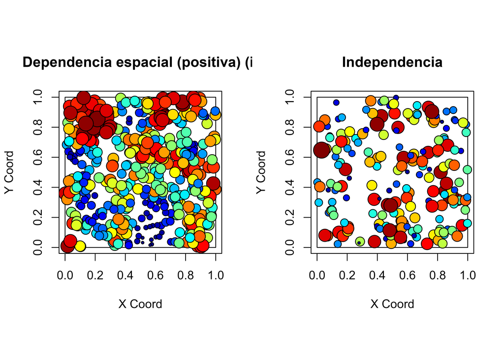

```r
points.geodata(sim3, main = "Independencia", col = tim.colors(), cex.max = 3)
```

```r
par(mfrow = c(1, 2))
set.seed(2022)
sim2 <- grf(441, grid = "reg", cov.pars = c(1, 0.25))
```

```
#> grf: generating grid  21  *  21  with  441  points
#> grf: process with  1  covariance structure(s)
#> grf: nugget effect is: tausq= 0
#> grf: covariance model 1 is: exponential(sigmasq=1, phi=0.25)
#> grf: decomposition algorithm used is:  cholesky
#> grf: End of simulation procedure. Number of realizations: 1
```

```r
image(sim2, main = "Dependencia espacial (positiva) (ii)", col = tim.colors())


# Independencia
set.seed(2022)
sim4 <- grf(441, grid = "reg", cov.pars = c(0.01, 0))
```

```
#> grf: generating grid  21  *  21  with  441  points
#> grf: process with  1  covariance structure(s)
#> grf: nugget effect is: tausq= 0
#> grf: covariance model 1 is a pure nugget effect
#> grf: decomposition algorithm used is:  cholesky
#> grf: End of simulation procedure. Number of realizations: 1
```

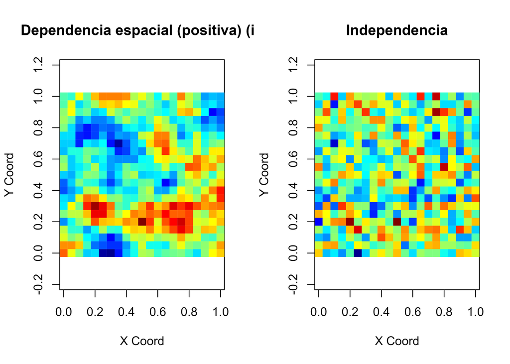

```r
image(sim4, main = "Independencia", col = tim.colors())
```